# Bootstrap ANOVA

ANOVA using the median absolute deviations

Solon Karapanagiotis

3 August 2016

**The [`plyr`](https://cran.r-project.org/web/packages/plyr/index.html) and [`car`](https://cran.r-project.org/web/packages/car/index.html) packages need to be installed.**

The data I use is the Chicks dataset. The dataset contains information over an experiment conducted to measure and compare the effectiveness of various feed supplements on the growth rate of chickens. Newly hatched chicks were randomly allocated into six groups, and each group was given a different feed supplement. Their weights (in grams) after six weeks are given along with the feed type. The data-frame contains 71 observations.

```r
data(chickwts)
str(chickwts)
```

```
## 'data.frame':    71 obs. of  2 variables:
##  $ weight: num  179 160 136 227 217 168 108 124 143 140 ...
##  $ feed  : Factor w/ 6 levels "casein","horsebean",..: 2 2 2 2 2 2 2 2 2 2 ...
```

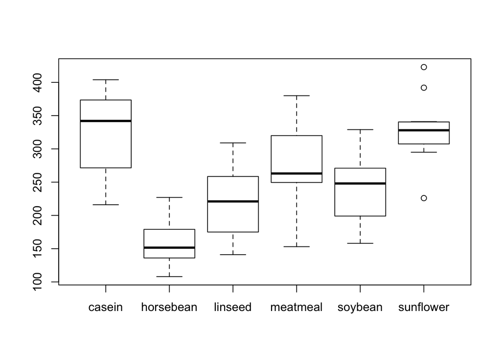

```r
boxplot(weight~feed, data=chickwts)
```

```r
library(plyr)
ddply(chickwts, c("feed"), summarise,
      N = length(weight), mean = round(mean(weight),2),
      sd = round(sd(weight),2))
```

```
##        feed  N   mean    sd
## 1    casein 12 323.58 64.43
## 2 horsebean 10 160.20 38.63
## 3   linseed 12 218.75 52.24
## 4  meatmeal 11 276.91 64.90
## 5   soybean 14 246.43 54.13
## 6 sunflower 12 328.92 48.84
```

The question of interest is if there a difference between the chick weights across the diet groups. In hypothesis framework this can be formulated as

$$H_0 : \mu_1 = \mu_2 = \ldots = \mu_6$$
$$H_a: \text{at least one pair of } \mu_1, \ldots , \mu_6 \text{ are different}$$

using $\mu_1$ to denote the mean weight of chickens fed on casein, $\mu_2$ to denote the mean weight of chickens fed on horsebean etc. To test $H_0$ the one-way ANOVA model can be formulated

$$Y_{ij}=\mu_i+\epsilon_{ij}$$

where $Y_{ij}$ is the weight of chick $i$ in diet group $j$, $\mu_i$ are the parameters and $\epsilon_{ij}$ are the error terms. The ANOVA table is given

```r
oneway.test(weight ~ feed, data=chickwts, var.equal = T)
```

```
##
##  One-way analysis of means
##
## data:  weight and feed
## F = 15.365, num df = 5, denom df = 65, p-value = 5.936e-10
```

- with the `var.equal = T` statement I treat the variances in the samples as equal. Motivation follows in the *Comments* below.

When $H_0$ holds the F statistic is distributed as $F(5,65)=2.35$. The p-value is the probability $P\big(F(5,65)>F_{stat}=15.37\big)=5^{-10}$. Based on this value we conclude that the data are not consistent with the null hypothesis. Hence, we can say that there are differences between the mean weights across the feed supplements (at 5% significance level).

*Comments*: The ANOVA model formulated above assumes that each probability distribution (for each diet group) is normal and they have the same variance (homoskedasticity). For the normality assumption we created the quantile-quantile plots for each feed type. For example, for the horsebean

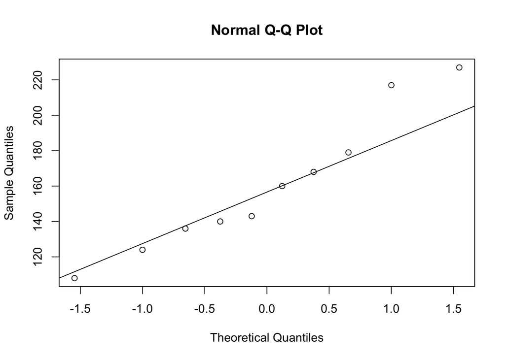

```r
# normality: Each probability distribution is normal
qqnorm(chickwts$weight[chickwts$feed == "horsebean"])
qqline(chickwts$weight[chickwts$feed == "horsebean"])
```

```r
library(car)
leveneTest(chickwts$weight ~ chickwts$feed)
```

```
## Levene's Test for Homogeneity of Variance (center = median)
##       Df F value Pr(>F)
## group  5  0.7493 0.5896
##       65
```

In the ANOVA calculation above the F statistic was based on the ratio of “between group” (SSTR=231129) and “within group” (SSE=195556) sum of squares (adjusted to the degree of freedoms).

```r
summary(aov(weight~feed, data=chickwts))
```

```
##             Df Sum Sq Mean Sq F value   Pr(>F)
## feed         5 231129   46226   15.37 5.94e-10 ***
## Residuals   65 195556    3009
## ---
## Signif. codes:  0 '***' 0.001 '**' 0.01 '*' 0.05 '.' 0.1 ' ' 1
```

The `aov()` is just another fuction to perform ANOVA. The results are the same, the output changes. For more background into ANOVA my favourite book is: Applied linear statistical models by Kutner, M. H., Nachtsheim, C. J., Neter, J., & Li, W. (2005).

Now, I formulate three other statistics, the sum of absolute deviances. I define the total sum of absolute deviances (ADTO):

$$ADTO = \sum_i{\sum_j|{Y_{ij}-M_{..}}|}$$

The *treatment sum of absolute deviances (ADTR)*:

$$ADTR = \sum_i{n_i|M_{i.}-M_{..}|}$$

The *error sum of absolute deviances (ADSE)*:

$$ADSE = \sum_i{\sum_j|{Y_{ij}-M_{i.}}|}$$

where $M_{i.}$ is the median over the of the j’th diet group and $M_{..}$ the overall median. The difference with the classical ANOVA is that the mean is substitued by the median and the sum of squared deviances by the sum of absolute deviances.

```r
##ADTO: total sum of absolute deviances
ADTO <- sum(abs(chickwts$weight-median(chickwts$weight)))

##ADSE error sum of absolute deviances
ADSE <- sum(abs(chickwts$weight[chickwts$feed == "horsebean"]- median(chickwts$weight[chickwts$feed == "horsebean"])))+
  sum(abs(chickwts$weight[chickwts$feed == "linseed"]- median(chickwts$weight[chickwts$feed == "linseed"])))+
  sum(abs(chickwts$weight[chickwts$feed == "soybean"]- median(chickwts$weight[chickwts$feed == "soybean"])))+
  sum(abs(chickwts$weight[chickwts$feed == "sunflower"]- median(chickwts$weight[chickwts$feed == "sunflower"])))+
  sum(abs(chickwts$weight[chickwts$feed == "meatmeal"]- median(chickwts$weight[chickwts$feed == "meatmeal"])))+
  sum(abs(chickwts$weight[chickwts$feed == "casein"]- median(chickwts$weight[chickwts$feed == "casein"])))

#ADTR: treatment absolute deviances
ADTR <- ADTO-ADSE

MADTR <- ADTR/5 #r-1 degress of freedom, r for the groups
MADE <- ADSE/(length(chickwts$weight)-6) #n-r degrees of freedom

F_tilde_star = MADTR/MADE
```

The table summarizes the above quantities

|  | DF | AD_ | MAD_ | $\tilde{F}$ |
| --- | --- | --- | --- | --- |
| Feed | 5 | 1654 | 330.6 | 7.29 |
| Residuals | 65 | 2944 | 45.29 |  |

The $\tilde{F}$ statistic is the ratio $\frac{MADTR}{MADSE}=\frac{330.6}{45.29}=7.29$.

Given the construction of the above statistics as deviations from the median a natural hypothesis to test is: \begin{equation}\label{eq:1} H_0 : m_1 = m_2 = \ldots = m_6 \end{equation}

$$H_a: \text{at least one pair of } m_1, \ldots , m_6 \text{ are different}$$

where $m_1$ to denote the median weight of chickens fed on casein, $m_2$ to denote the median weight of chickens fed on horsebean etc.

Since we do not know the theoretical distribution of $\tilde{F}$ we will use parametric bootstrap to simulate the theoretical distribution $\tilde{F^*}$ under the null hypothesis. To keep in line with the assumptions of the classical ANOVA since they were not rejected (see *Comments* above) I assume that each $Y_{ij}$ comes from a normal distribution with median=258 and standard deviation=54.6: $Y_{ij} \sim{} N(258,54.6)$. The median corresponds to the median of the whole dataset. Since we assume normal distribution mean=median. The standard deviation is the pooled SD from the dataset. I choose to use the pooled value based on the Levene’s test, where heteroskedasticity was rejected.

```r
median(chickwts$weight)
```

```
## [1] 258
```

```r
# since can reject homogeneity we assume pooled sd
sqrt(mean(with(chickwts,tapply(weight,feed,var))))
```

```
## [1] 54.6188
```

The bootstrap algorithm proceeds as follows:  
1. $n_t$ values for $Y_{ij}$ are sampled from $N(258,54.6)$ ($n_t$ is the number of chicks in each feed category),  
2. $ADTR$, $ADSE$, $MADTR$, $MADE$ and $\tilde{F^*}$ are computed  
3. steps 1 and 2 are repeated R=5000 times

```r
## parametric bootstrap
medianstar = median(chickwts$weight)  #the median (=mean) value of the nomral distribution
sdstar = sqrt(mean(with(chickwts,tapply(weight,feed,var))))   #the pooled sd value of the nomral distribution
simfeed = chickwts$feed   # the feed categories
R = 5000  # number of bootstrap replications
ADTO <- numeric(R) # empty vectors of the quantities I need. They will hold the simulated values later.
ADSE <- numeric(R)
ADTR <- numeric(R)
MADE <- numeric(R)
MADTR <- numeric(R)
F_tilde_param = numeric(R)
set.seed(23455)

#the groups A-F are not needed here but I left for convenience (I used them in the non-paramtric later)
for (i in 1:R) {
  groupA = rnorm(12, mean=medianstar, sd=sdstar) # 6 groups, one for each feed supplement
  groupB = rnorm(10, mean=medianstar, sd=sdstar)
  groupC = rnorm(12, mean=medianstar, sd=sdstar)
  groupD = rnorm(11, mean=medianstar, sd=sdstar)
  groupE = rnorm(14, mean=medianstar, sd=sdstar)
  groupF = rnorm(12, mean=medianstar, sd=sdstar)
  sim_weight = c(groupA,groupB,groupC,groupD,groupE,groupF)
  simdata = data.frame(sim_weight,simfeed)

  ADTO[i] <- sum(abs(simdata$sim_weight-median(simdata$sim_weight))) #the index i means that I calculate the quantity (e.g ADTO) for each replication R (from 1 to R=5000)

  ## ADSE error sum of absolute deviances
  ADSE[i] <- sum(abs(simdata$sim_weight[simdata$simfeed == "horsebean"]- median(simdata$sim_weight[simdata$simfeed == "horsebean"])))+
    sum(abs(simdata$sim_weight[simdata$simfeed == "linseed"]- median(simdata$sim_weight[simdata$simfeed == "linseed"])))+
    sum(abs(simdata$sim_weight[simdata$simfeed == "soybean"]- median(simdata$sim_weight[simdata$simfeed == "soybean"])))+
    sum(abs(simdata$sim_weight[simdata$simfeed == "sunflower"]- median(simdata$sim_weight[simdata$simfeed == "sunflower"])))+
    sum(abs(simdata$sim_weight[simdata$simfeed == "meatmeal"]- median(simdata$sim_weight[simdata$simfeed == "meatmeal"])))+
    sum(abs(simdata$sim_weight[simdata$simfeed == "casein"]- median(simdata$sim_weight[simdata$simfeed == "casein"])))

  #ADTR: treatment absolute deviances
  ADTR[i] <- ADTO[i]-ADSE[i]

  MADTR[i] <- ADTR[i]/5 #r-1 degress of freedom, r for the groups
  MADE[i] <- ADSE[i]/(length(chickwts$weight)-6) #n-r degrees of freedom

  F_tilde_param[i] = MADTR[i]/MADE[i] #final step calculate the F_tilde for each replication

}
```

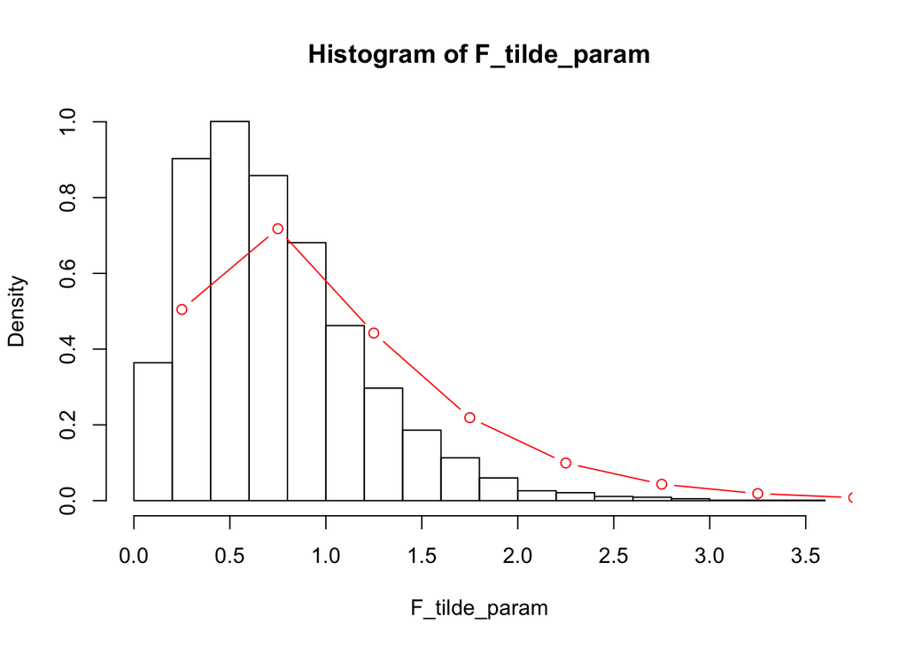

```r
hist(F_tilde_param, prob=T)
x=seq(.25,5.25,.5)
points(x,y=df(x,5,66),type="b",col="red")
```

The Monte-Carlo p-value is calculated as
$$p=\frac{1+ \#(\tilde{F^*} > \tilde{F})}{R+1}$$

```r
(p_value <- (1+sum(F_tilde_param > F_tilde_star))/(R+1))
```

```
## [1] 0.00019996
```

The small p-value allows us to reject the null hypothesis and conclude the median weights are different for each diet group of chickens.

Another alternative is not to assume a parametric model for $Y_{ij}$. In that case the bootstrap algorithm proceeds as follows:  
1. first I center all the groups on the same median (zero), in order to simulate under $H_0$, and left the variance and shape of the individual group distributions undisturbed  
2. $n_t$ values for $Y_{ij}$ are sampled from the empirical distributions  
3. $ADTR$, $ADSE$, $MADTR$, $MADE$ and $\tilde{F^*}$ are computed  
4. steps 2 and 3 are repeated 5000 times

```r
## Non-parametric bootstrap
medianstar = with(chickwts, tapply(weight,feed,median))
grpA = chickwts$weight[chickwts$feed == "horsebean"] - medianstar["horsebean"]
grpB = chickwts$weight[chickwts$feed == "linseed"] - medianstar["linseed"]
grpC = chickwts$weight[chickwts$feed == "soybean"] - medianstar["soybean"]
grpD = chickwts$weight[chickwts$feed == "sunflower"] - medianstar["sunflower"]
grpE = chickwts$weight[chickwts$feed == "meatmeal"] - medianstar["meatmeal"]
grpF = chickwts$weight[chickwts$feed == "casein"] - medianstar["casein"]
simfeed = chickwts$feed
R = 5000
F_tilde_nonparam <- numeric(R)
ADTO <- numeric(R)
ADSE <- numeric(R)
ADTR <- numeric(R)
MADE <- numeric(R)
MADTR <- numeric(R)

set.seed(23456)
for (i in 1:R) {
  groupA = sample(grpA, size=10, replace=T)
  groupB = sample(grpB, size=12, replace=T)
  groupC = sample(grpC, size=14, replace=T)
  groupD = sample(grpD, size=12, replace=T)
  groupE = sample(grpE, size=11, replace=T)
  groupF = sample(grpF, size=12, replace=T)
  sim_weight = c(groupA,groupB,groupC,groupD,groupE,groupF)
  simdata = data.frame(sim_weight,simfeed)

  ADTO[i] <- sum(abs(simdata$sim_weight-median(simdata$sim_weight)))

  ##ADSE error sum of absolute deviances
  ADSE[i] <- sum(abs(simdata$sim_weight[simdata$simfeed == "horsebean"]- median(simdata$sim_weight[simdata$simfeed == "horsebean"])))+
    sum(abs(simdata$sim_weight[simdata$simfeed == "linseed"]- median(simdata$sim_weight[simdata$simfeed == "linseed"])))+
    sum(abs(simdata$sim_weight[simdata$simfeed == "soybean"]- median(simdata$sim_weight[simdata$simfeed == "soybean"])))+
    sum(abs(simdata$sim_weight[simdata$simfeed == "sunflower"]- median(simdata$sim_weight[simdata$simfeed == "sunflower"])))+
    sum(abs(simdata$sim_weight[simdata$simfeed == "meatmeal"]- median(simdata$sim_weight[simdata$simfeed == "meatmeal"])))+
    sum(abs(simdata$sim_weight[simdata$simfeed == "casein"]- median(simdata$sim_weight[simdata$simfeed == "casein"])))

  #ADTR: treatment absolute deviances
  ADTR[i] <- ADTO[i]-ADSE[i]

  MADTR[i] <- ADTR[i]/5 #r-1 degress of freedom, r for the groups
  MADE[i] <- ADSE[i]/(length(chickwts$weight)-6) #n-r degrees of freedom

  F_tilde_nonparam[i] = MADTR[i]/MADE[i]

}
```

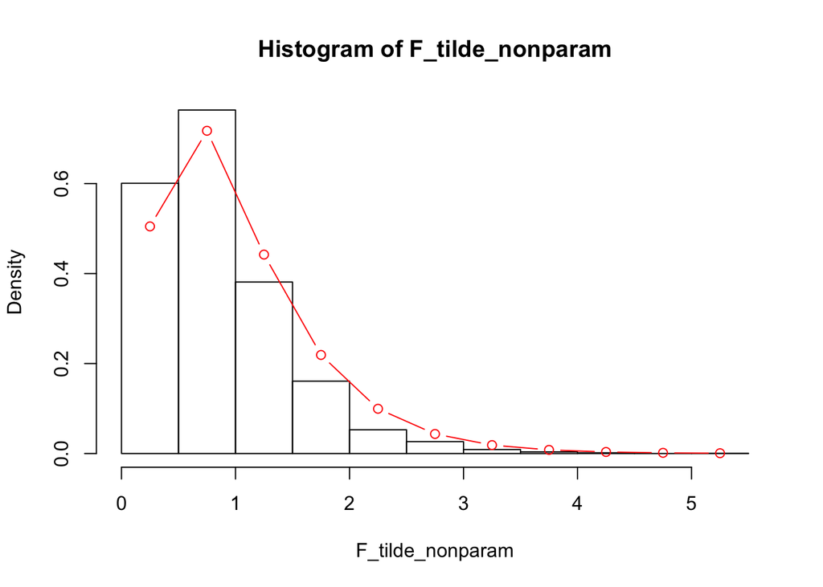

```r
hist(F_tilde_nonparam, prob=T)
x=seq(.25,5.25,.5)
points(x,y=df(x,5,65),type="b",col="red")
```

```r
(pvalue <- (1+sum(F_tilde_nonparam > F_tilde_star))/(R+1))
```

```
## [1] 0.00019996
```

Summarising,

The three distributions are pictured in the figure below. First of all, we notice that the $\tilde{F^*}_{parametric}$ and $\tilde{F^*}_{non-parametric}$ are very similar to each other. This can be considered as evidence in favour of the parametric assumptions we adopted earlier. Secondly, we could safely say that all of three would give relatively the same result for a statistic $>3$. But in earlier instances probably the p-values would be considerably divergent. This divergence would possibly be more evident between the parametric $\tilde{F^*}$ and $F(5,65)$. In any case the difference in the p-value will depend highly on the statistic since the relative discrepancy of the three distributions is different for different values of the x-axis.

To conclude, it would be inappropriate to use the theoretical results of the classical ANOVA to test the hypothesis about medians. Even though the results would be qualitatively the same in our example this may not be the case in other scenarios.

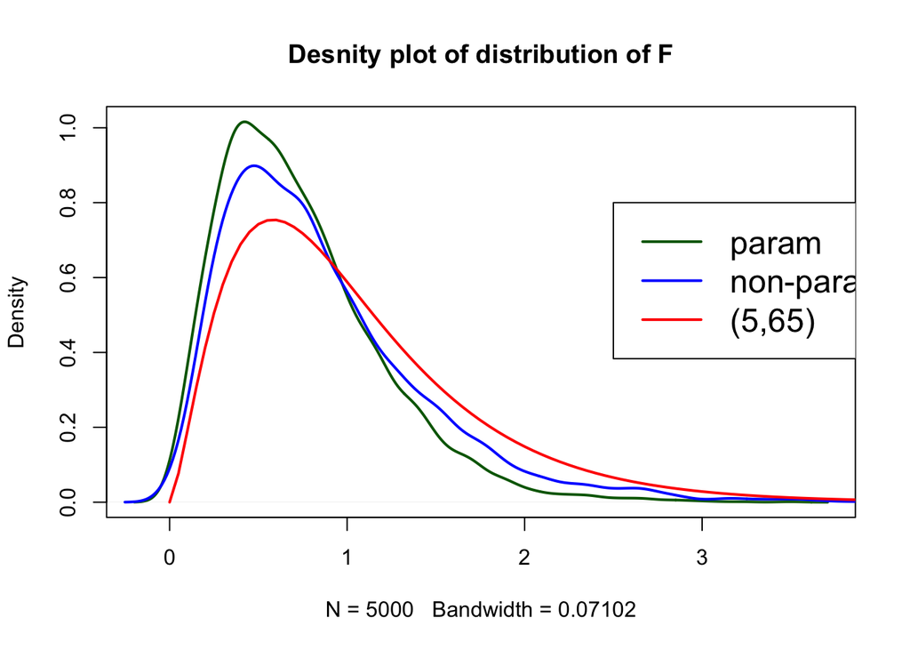

```r
y <- seq(0,5.25,.05)
plot(density(F_tilde_param), col="dark green", main="Desnity plot of distribution of F",lwd=2)
lines(density(F_tilde_nonparam), col="blue", lwd=2)
points(y,y=df(y,5,66), type="l", col="red", lwd=2)
legend(2.5,0.8, c("param", "non-param", "(5,65)"), lty=1, col=c("dark green", "blue", "red"), cex=1.5,lwd=2)
```